# 09. Multiple regression principles

Notes and in-class exercises

# Notes

- Download the `.qmd` file for this activity here.
- **File organization:** Save this file in the “Activities” subfolder of your “STAT155” folder.
- Open the `qmd` file in RStudio, and use it to type your answers/code to the exercises and reflection on the in-class activities.

## Learning goals

Working with multiple predictors in our plots and models can get complicated! There are no *recipes* for this process. BUT there are some guiding *principles* that assist in long-term retention, deeper understanding, and the ability to generalize our tools in new settings. By the end of this lesson, you should be familiar with some general *principles* for…

- incorporating additional quantitative or categorical predictors in a visualization
- how additional quantitative or categorical predictors impact the physical representation of a model
- interpreting quantitative or categorical coefficients in a multiple regression model

## Readings and videos

Please watch the following video **before** class.

- [Interpreting multivariate models](https://www.youtube.com/watch?v=DnXwu1OWgMM) ([slides](https://drive.google.com/file/d/1fiJL1IbReg6RJmjxRideYzYTyQtWR3Or/view?usp=sharing))

# Exercises

Let’s revisit the bikeshare data:

```r
# Load packages & import data
library(readr)
library(ggplot2)
library(dplyr)

bikes <- read_csv("https://mac-stat.github.io/data/bikeshare.csv") %>%
  rename(rides = riders_registered)
```

Our goal is to understand how / why registered ridership from day to day. To this end, we’ll build various **multiple linear regression** models of `rides` by different combinations of the possible predictors:

```r
# Check out the data
head(bikes)
```

## Exercise 1: Review visualization

Let’s build a model of `rides` by `windspeed` (quantitative) and `weekend` status (categorical). Plot & describe, in words, the relationship between these 3 variables. Include a representation of the regression model.

```r
# Plot of rides vs windspeed & weekend
# HINT: Start with a plot of rides vs windspeed
```

## Exercise 2: Review model

Let’s build the model:

```r
bike_model_1 <- lm(rides ~ windspeed + weekend, data = bikes)
coef(summary(bike_model_1))
```

The model formula thus is:

E[rides | windspeed, weekendTRUE] = 4738.38 - 63.97 * windspeed - 925.16 * weekendTRUE

This model formula is represented by 2 lines, one corresponding to weekends and the other to weekdays. Specify the corresponding sub-model formulas:

weekdays: rides = ___ - ___ windspeed

weekends: rides = ___ - ___ windspeed

## Exercise 3: Review coefficient interpretation

1. The intercept coefficient, 4738.38, represents the *intercept* of the sub-model for weekdays, the reference category. What’s its *contextual* interpretation?
2. The `windspeed` coefficient, -63.97, represents the *shared slope* of the weekend and weekday sub-models. What’s its *contextual* interpretation?
3. The `weekendTRUE` coefficient, -925.16, represents the *change in intercept* for the weekend vs weekday sub-model. What’s its *contextual* interpretation?

## Exercise 4: 2 categorical predictors – visualization

Thus far, we’ve explored a couple examples of multiple regression models that have 2 predictors, 1 quantitative and 1 categorical. So what happens when *both* predictors are categorical?! To this end, let’s model `rides` by `weekend` status and `season`.

The below code plots `rides` vs `season`. Modify this code to *also* include information about `weekend`. HINT: Remember the visualization *principle* that additional categorical predictors require some sort of grouping mechanism / mechanism that distinguishes between the 2 groups.

```r
# rides vs season
bikes %>%
  ggplot(aes(y = rides, x = season)) +
  geom_boxplot()

# rides vs season AND weekend
# bikes %>%
#   ggplot(aes(y = rides, x = season, ___ = ___)) +
#   geom_boxplot()
```

## Exercise 5: follow-up

1. Describe (in words) the relationship of ridership with season & weekend status.
2. A model of `rides` by `season` alone would be represented by only 4 expected outcomes, 1 for each season. Considering this and the plot above, how do you *anticipate* a model of `rides` by `season` and `weekend` status will be represented?
   - 2 lines, 1 for each weekend status
   - 8 lines, 1 for each possible combination of season & weekend
   - 2 expected outcomes, 1 for each weekend status
   - 8 expected outcomes, 1 for each possible combination of season & weekend

## Exercise 6: 2 categorical predictors – build the model

Let’s build the multiple regression model of `rides` vs `season` and `weekend`:

```r
bike_model_2 <- lm(rides ~ weekend + season, bikes)
coef(summary(bike_model_2))
```

Thus the model formula is

E[rides | weekend, season] = 4260.45 - 912.33 weekendTRUE - 116.38 seasonspring + 438.44 seasonsummer - 1719.06 seasonwinter

1. Use this model to predict the ridership on the following days:

```r
# a fall weekday
# 4260.45 - 912.33*___ - 116.38*___  + 438.44*___ - 1719.06*___

# a winter weekday
# 4260.45 - 912.33*___ - 116.38*___  + 438.44*___ - 1719.06*___

# a fall weekend day
# 4260.45 - 912.33*___ - 116.38*___  + 438.44*___ - 1719.06*___

# a winter weekend day
# 4260.45 - 912.33*___ - 116.38*___  + 438.44*___ - 1719.06*___
```

2. We only made 4 predictions here. How many *possible* predictions does this model produce? Is this consistent with your intuition in the previous exercise?

## Exercise 7: 2 categorical predictors – interpret the model

Use your above predictions and visualization to fill in the below interpretations of the model coefficients. Hint: What is the consequence of plugging in 0 or 1 for the different `weekend` and `season` categories?

1. Interpreting 4260: We expect there to be 4260 riders on (weekdays/weekends) during the (fall/spring/summer/winter).
2. Interpreting -912: *In any season*, we expect there to be 912 (more/fewer) riders on weekends than on ___.
3. Interpreting -1719: *On both weekdays and weekends*, we expect there to be 1719 (more/fewer) riders in winter than in ___.

## Exercise 8: 2 quantitative predictors – visualization

Next, consider the relationship between `rides` and 2 *quantitative* predictors: `windspeed` and `temp_feel`. Check out 2 plots of this relationship below. These reflect the visualization *principle* that quantitative variables require some sort of numerical scaling mechanism – `rides` and `windspeed` get numerical axes, and `temp_feel` gets size and color scales.

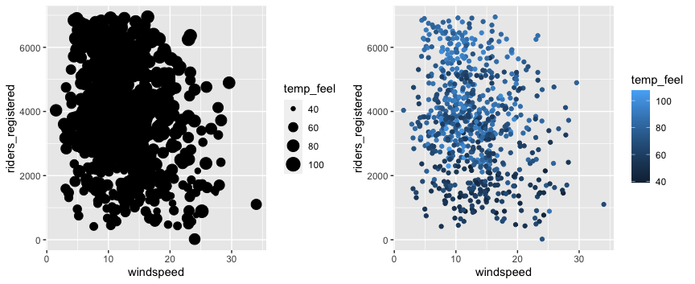

Modify the code below to recreate these 2 plots.

```r
# Left plot
# bikes %>%
#   ggplot(aes(y = rides, x = windspeed, ___ = ___)) +
#   geom_point(alpha=0.5)

# Right plot
# bikes %>%
#   ggplot(aes(y = rides, x = windspeed, ___ = ___)) +
#   geom_point()
```

## Exercise 9: follow-up

1. Describe (in words) the relationship of ridership with windspeed & temperature.
2. A model of `rides` by `windspeed` alone would be represented by 1 line. How do you *anticipate* a model of `rides` by `windspeed` and `temp_feel` status will be represented? HINT: Think about the 3D scatterplot.

## Exercise 10: 2 quantitative predictors – modeling

Let’s build the multiple regression model of `rides` vs `windspeed` and `temp_feel`:

```r
bike_model_3 <- lm(rides ~ windspeed + temp_feel, bikes)
coef(summary(bike_model_3))
```

Thus the model formula is

E[rides | windspeed, temp_feel] = -24.06 - 36.54 windspeed + 55.52 temp_feel

This is the formula of a *plane*, drawn here:

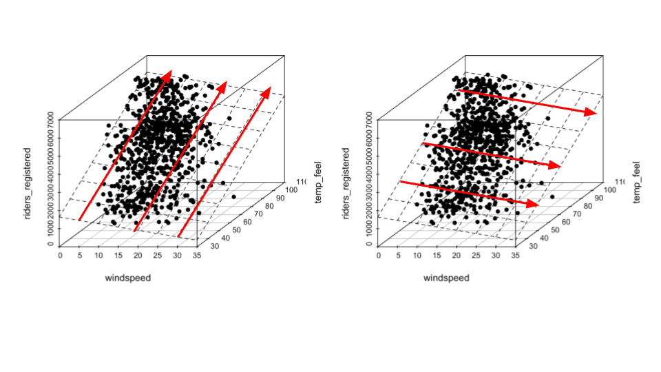

1. Interpret the intercept coefficient, -24.06, in context.
2. Interpret the `windspeed` coefficient, -36.54, in context. HINT: This is the slope of the red lines in the *right* plot, drawn at 3 arbitrary temperatures (40, 60, and 90 degrees).
3. Interpret the `temp_feel` coefficient, 55.52, in context. HINT: This is the slope of the red lines in the left plot, drawn at 3 arbitrary wind speeds (5, 20, and 30 mph).

## Exercise 11: Which is best?

We’ve now observed 3 different models of ridership, each having 2 predictors. The R-squared values of these models, along with those of the simple linear regression models with each predictor alone, are summarized below.

| model | predictors | R-squared |
| --- | --- | --- |
| `bike_model_1` | `windspeed` & `weekend` | 0.119 |
| `bike_model_2` | `weekend` & `season` | 0.349 |
| `bike_model_3` | `windspeed` & `temp_feel` | 0.310 |
| `bike_model_4` | `windspeed` | 0.047 |
| `bike_model_5` | `temp_feel` | 0.296 |
| `bike_model_6` | `weekend` | 0.074 |
| `bike_model_7` | `season` | 0.279 |

1. Which model does the best job of explaining the variability in ridership from day to day?
2. If you could only pick one predictor, which would it be?
3. What happens to R-squared when we add a second predictor to our model, and why does this make sense? For example, how does the R-squared for model 1 (with both windspeed and weekend) compare to those of model 4 (only windspeed) and model 6 (only weekend)?
4. Are 2 predictors always better than 1? Provide evidence and explain why this makes sense.

## Exercise 12: Principles of interpretation

These exercises have revealed some **principles** behind interpreting model coefficients, summarized below. Review and confirm that these make sense.

**Principles of interpretation**

Consider a multiple linear regression model:

$$E[y | x_1, x_2, ..., x_p] = \beta_0 + \beta_1 x_1 + \beta_2 x_2 + ... + \beta_p x_p$$

We can interpret the coefficients as follows:

- $\beta_0$ (“beta 0”) is the y-intercept. It describes the typical value of $y$ when $x_1, x_2,..., x_k$ are all 0, ie. when all quantitative predictors are set to 0 and the categorical predictors are set to their reference levels.
- $\beta_i$ (“beta i”) is the coefficient of $x_i$.
  - If $x_i$ is quantitative, $\beta_i$ describes the typical change in $y$ per 1-unit increase in $x_i$ while at a fixed set of the other $x$.
  - If $x_i$ represents a category of a categorical variable, $\beta_i$ describes the typical change in $y$ when we move to this category from the reference category while at a fixed set of the other $x$.

# Extra practice

The following exercises provide extra practice. If you don’t get to these during class, you’re encouraged to try them outside class.

## Exercise 13: Practice 1

Consider the relationship of `rides` vs `weekend` and `weather_cat`.

1. Construct a visualization of this relationship.
2. Construct a model of this relationship.
3. Interpret the first 3 model coefficients.

## Exercise 14: Practice 2

Consider the relationship of `rides` vs `temp_feel` and `humidity`.

1. Construct a visualization of this relationship.
2. Construct a model of this relationship.
3. Interpret the first 3 model coefficients.

## Exercise 15: Practice 3

Consider the relationship of `rides` vs `temp_feel` and `weather_cat`.

1. Construct a visualization of this relationship.
2. Construct a model of this relationship.
3. Interpret the first 3 model coefficients.

## Exercise 16: CHALLENGE

We’ve explored models with 2 predictors. What about 3 predictors?! Consider the relationship of `rides` vs `temp_feel`, `humidity`, AND `weekend`.

1. Construct a visualization of this relationship.
2. Construct a model of this relationship.
3. Interpret each model coefficient.
4. If you had to *draw* the shape of the model trend, what would it look like: a line, parallel lines, a plane, parallel planes?

Solutions